# Aplicaciones del Big Data en la empresa

Fernández Hernández, Alberto

15/03/2021

**Nota**: para la realización de la práctica, y a lo largo del concurso, **se ha tomado como base el *score* obtenido en el modelo 2 realizado en clase:**

1. Selección de variables numéricas y categóricas (con al menos dos categorías y menos de 1000), además de descartar las variables duplicadas *payment_type* y *quantity_group*, obteniendo la siguiente puntuación:

|  | Train.accuracy | Data.Submission |
| --- | --- | --- |
| Num + Cat (> 1 & < 1000) sin duplicados | 0.8168687 | 0.8128 |

# 1. Carga de datos y librerías

Para la realización de la práctica, los ficheros utilizados son los siguientes:

1. *train_values.csv*: **fichero con el conjunto de variables y observaciones con los que entrenar el modelo**.
2. *train_labels.csv*: **fichero con las variables objetivo de cada una de las observaciones en *train_values.csv***:
- 2.1 *functional*
- 2.2 *non functional*
- 2.3 *functional needs repair*
3. *test_values.csv*: **fichero de prueba con el que maximizar las predicciones obtenidas con el correspondiente modelo**

En relación con las librerías empleadas, debemos destacar las siguientes:

```r
#--- Librerias empleadas
suppressPackageStartupMessages({
  library(dplyr)           # Manipulacion de datos
  library(data.table)      # Lectura y escritura de ficheros
  library(ggplot2)         # Representacion grafica
  library(inspectdf)       # EDAs automaticos
  library(ranger)          # randomForest (+ rapido que caret)
  library(forcats)         # Tratamiento de variables categoricas
  library(tictoc)          # Calculo de tiempo de ejecucion
  library(missRanger)      # Imputacion de valores NA
  library(knitr)           # Generacion de informes (formateo de tablas)
  library(gmt)             # Calculo de la distancia geografica
  library(stringi)         # Tratamiento de strings
  library(FeatureHashing)  # Hashing Encoding
  library(dataPreparation) # Target encoding
  library(embed)           # Word-Embeddings
  library(recipes)         # Definicion de recetas (preprocesamiento de datos + FE)
})
```

```r
#--- Carga de ficheros train y test
dattrainOr    <- fread(file = "../data/train_values.csv", data.table = FALSE )
dattrainLabOr <- fread(file = "../data/train_labels.csv", data.table = FALSE )
dattestOr     <- fread(file = "../data/test_values.csv", data.table = FALSE  )
```

# 2. Desarrollo durante el concurso

## 2.1 Análisis de variables existentes

En primer lugar, en base a las funciones disponibles en la librería *inspectdf*, **se extrajo un esquema inicial con las variables existentes en el conjunto de datos y su correspondiente tipo**:

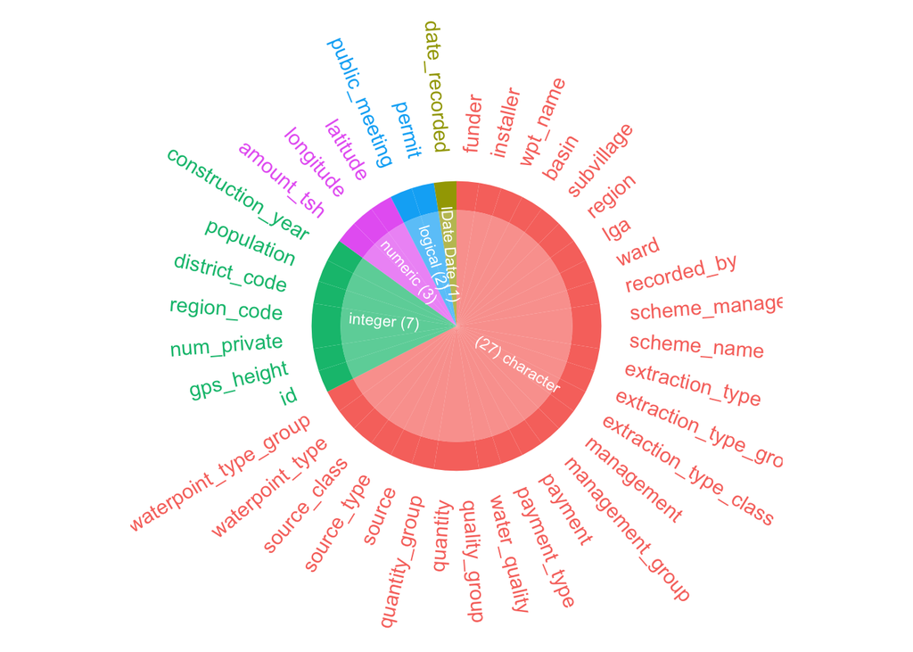

```r
# Analizamos el tipo de dato en cada variable
show_plot(inspect_types(dattrainOr))
```

En conjunto, nos encontramos con:

1. **27 variables variables de tipo carácter (categóricas)**
2. **10 variables numéricas (entre *integer* y *numeric*)**
3. **2 variables lógicas**
4. **1 variable tipo fecha**

Por tanto, del mismo modo que lo realizado en el modelo 2:

```r
#-- Variables categoricas
datcat_df <- dattrainOr %>% select(where(is.character))
```

```r
# Mediante un bucle for,
numlev_df <- data.frame(
                          "vars" = names(datcat_df),
                           "levels" = apply(datcat_df, 2,
                                  function(x) length(unique(x)))

                        )
# Eliminamos los nombres de fila
rownames(numlev_df) <- NULL

kable(numlev_df %>% arrange(levels))
```

| vars | levels |
| --- | --- |
| recorded_by | 1 |
| source_class | 3 |
| management_group | 5 |
| quantity | 5 |
| quantity_group | 5 |
| quality_group | 6 |
| waterpoint_type_group | 6 |
| extraction_type_class | 7 |
| payment | 7 |
| payment_type | 7 |
| source_type | 7 |
| waterpoint_type | 7 |
| water_quality | 8 |
| basin | 9 |
| source | 10 |
| management | 12 |
| scheme_management | 13 |
| extraction_type_group | 13 |
| extraction_type | 18 |
| region | 21 |
| lga | 125 |
| funder | 1898 |
| ward | 2092 |
| installer | 2146 |
| scheme_name | 2697 |
| subvillage | 19288 |
| wpt_name | 37400 |

Por tanto, escogemos desde la variable *source_class* hasta *lga*, dado que *recorded_by* solo presenta una única categoría:

```r
#-- Conservamos variables con categorias > 1 & < 1000
vars_gd <- numlev_df %>%
  filter(levels < 1000, levels > 1) %>%
  select(vars)
datcat_gd <- datcat_df[ , vars_gd$vars]
```

```r
#-- Variables numericas
datnum_df <- dattrainOr %>% select(where(is.numeric))
```

```r
# Unificamos ambos tipos de variables...
datnumcat_df <- cbind(datnum_df, datcat_gd)
```

```r
# ...Como tambien la variable objetivo
dattrainOrlab <- merge(
  datnumcat_df, dattrainLabOr,
  by.x = c('id'), by.y = c('id'),
  sort = FALSE
)
```

2. **Eliminación de variables con información duplicada**, concretamente *payment_type* y *quantity_group*:

```r
dattrainOrlab$payment_type <- NULL
dattrainOrlab$quantity_group <- NULL
```

## 2.1 Tratamiento de valores anómalos

Una vez pre-procesado el conjunto de entrenamiento, una de las primeras ideas que se tuvo en cuenta fue **el tratamiento de valores anómalos, concretamente a cero, de determinadas variables**, anotados durante la primera fase de análisis exploratorio realizada en clase:

1. *construction_year*
2. *gps_height*: en el caso de la altura GPS, **no se han considerado los valores negativos como valores anómalos**, principalmente porque, traslando el problema a un entorno real, es posible la existencia de alturas negativas (regiones situadas por debajo del nivel del mar).
3. *longitude*

Sobre dichas variables podemos observar en los siguientes histogramas una elevada concentración de valores a cero:

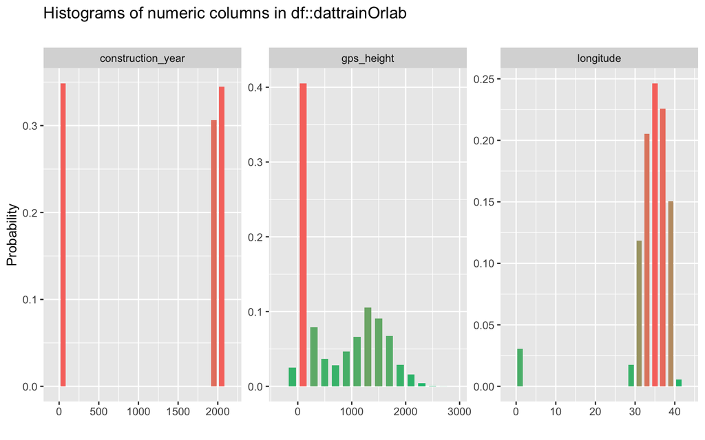

```r
# Graficos de distribucion
# Histograms for numeric columns
show_plot(
  inspect_num(dattrainOrlab[c("construction_year",
                              "gps_height",
                              "longitude")])

)
```

Por tanto, para eliminar y posteriormente imputar dichos ceros, **haremos uso de una función denominada impute_zeros**, la cual permite establecer inicialmente a NA los valores a cero, así como su posterior imputación haciendo uso de la librería *missRanger*.

**Nota**: a lo largo de la memoria se definen varias funciones que se emplean comunmente tanto en el concurso como en el desarrollo individual, evitando con ello la redundancia de código.

```r
# Funcion para la imputacion de ceros con missRanger
impute_zeros <- function(data, column, k, num_trees, impute = TRUE, seed = 1234) {
  new_feature <- paste0("fe_", column)

  data[, new_feature] <- data[, column]
  data[, new_feature] <- ifelse(
                            data[, new_feature] == 0,
                            NA,
                            data[, new_feature]
  )
  original_data       <- data[, new_feature]

  data[, column]      <- NULL

  if (impute == TRUE) {
    data_imp <- missRanger(
                            data,
                            pmm.k = k,
                            num.trees = num_trees,
                            seed = seed
                           )
    # Finalmente, creamos una nueva columna binaria
    # 1 = el valor era NA; 0 = No
    new_feature_na      <- paste0("fe_", column, "_na")
    data_imp[, new_feature_na] <- ifelse(
                                    is.na(original_data),
                                    1,
                                    0
    )
  }
  return(data_imp)
}
```

Una vez definida la funcion, imputamos cada una de las columnas anteriores, **no sin antes eliminar la columna *status_group*, con el objetivo de evitar que la imputación también dependa del valor de la variable objetivo**. Además, en lugar de utilizar k = 3 como número de vecinos, durante el concurso se aumentó dicho valor a 5, con el objetivo de comprobar si el resultado mejoraba con respecto a lo obtenido en clase:

```r
# Almacenamos en un vector la variable objetivo
status_group_vector        <- dattrainOrlab$status_group
dattrainOrlab$status_group <- NULL
```

```r
#--- construction_year
#
dattrainOrlab_imp <- impute_zeros(dattrainOrlab,
                                  column = "construction_year",
                                  k = 5,
                                  num_trees = 100)
```

```r
#--- gps_heigth
dattrainOrlab_imp <- impute_zeros(dattrainOrlab_imp,
                                  column = "gps_height",
                                  k = 5,
                                  num_trees = 100)
```

```r
#--- longitude
dattrainOrlab_imp <- impute_zeros(dattrainOrlab_imp,
                                  column = "longitude",
                                  k = 5,
                                  num_trees = 100)
```

Tras la imputación, añadimos nuevamente la variable objetivo al conjunto de entrenamiento:

```r
dattrainOrlab_imp$status_group <- status_group_vector
dattrainOrlab_imp$status_group <- as.factor(dattrainOrlab_imp$status_group)
```

En relación con el conjunto *test*, dado que no debemos aplicar la imputación de los valores *missing* a partir del propio conjunto *test*, a cada valor NA (es decir, igual a cero), se tomó la decisión de **imputarlo por un valor muy diferente al resto de la población**, concretamente 99999, así como añadir una columna binaria adicional que indice si el valor imputado era o no un valor *missing*:

```r
dattestOr_imp <- dattestOr

for(column in c("construction_year", "gps_height", "longitude")) {
  new_feature <- paste0("fe_", column)
  dattestOr_imp[, new_feature] <- ifelse(
                                          dattestOr_imp[, column] == 0,
                                          99999,
                                          dattestOr_imp[, column]
  )
  dattestOr_imp[, column] <- NULL

  new_feature_na <- paste0("fe_", column, "_na")
  dattestOr_imp[, new_feature_na] <- ifelse(
                                          dattestOr_imp[, new_feature] == 99999,
                                          1,
                                          0
  )
}
```

Una vez imputadas las variables, por medio de la función *ranger* creamos un primer modelo de *Random Forest*:

```r
# Funcion que devuelve un modelo Random Forest entrenado
fit_random_forest <- function(formula, data, num_trees = 500, mtry = NULL, seed = 1234) {
  tic()
  my_model <- ranger(
    formula,
    importance = 'impurity',
    data       = data,
    num.trees = num_trees,
    mtry = mtry,
    verbose = FALSE,
    seed = seed
  )
  # **Estimacion** del error / acierto **esperado**
  success <- 1 - my_model$prediction.error
  print(success)
  toc()

  return(my_model)
}
```

De forma adicional, creamos una función que permita crear un grafico con la importancia de las variables del modelo pasado como argumento, así como almacenar el gráfico en disco:

```r
#--- Funcion para pintar importancia de variables (ademas de guardar el grafico)
save_importance_ggplot <- function(model, path) {
  impor_df <- as.data.frame(model$variable.importance)
  names(impor_df)[1] <- c('Importance')
  impor_df$vars <- rownames(impor_df)
  rownames(impor_df) <- NULL

  print(ggplot(impor_df, aes(fct_reorder(vars, Importance), Importance)) +
    geom_col(group = 1, fill = "darkred") +
    coord_flip() +
    labs(x = 'Variables', y = 'Importancia', title = 'Importancia Variables') +
    theme_bw())
  ggsave(path)
}
```

```r
formula    <- as.formula('status_group~.')

my_model_1 <- fit_random_forest(formula, dattrainOrlab_imp)
```

```
[1] 0.8101178
34.328 sec elapsed
```

Tras crear el modelo, guardamos el gráfico con la importancia de cada una de las variables:

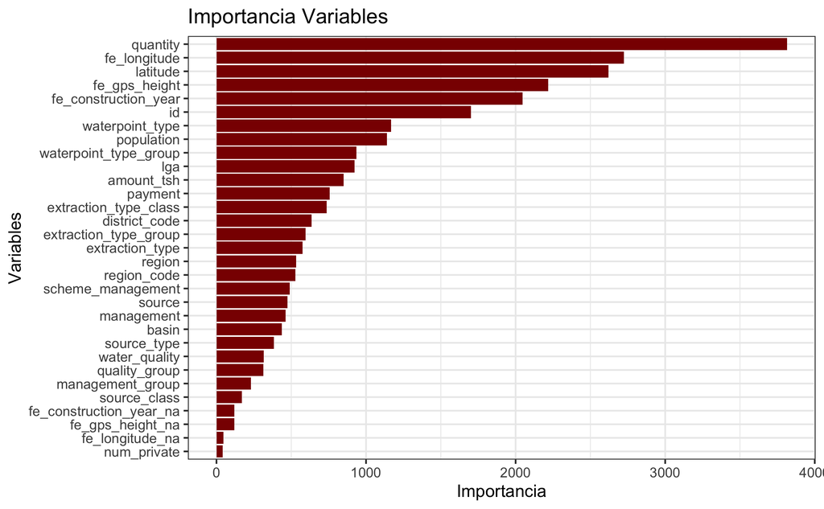

```r
save_importance_ggplot(my_model_1, '../charts/01_num_cat_menos1000_todo_imp.png')
```

Analizando el gráfico de importancia, observamos que las variables imputadas (año de construcción, altura GPS y longitud) presentan una elevada importancia. No obstante, las variables "_na" no parecen aportar una importancia relevante al modelo. No obstante, realizamos las predicciones y comparamos el *score* obtenido:

```r
#--- Funcion para realizar prediccion sobre el modelo pasado como parametro
make_predictions <- function(model, test_data) {
  # Prediccion
  my_pred <- predict(model, test_data)

  # Submission
  my_sub <- data.table(
    id = test_data[, "id"],
    status_group = my_pred$predictions
  )

  return(my_sub)
}
```

```r
my_sub_1 <- make_predictions(my_model_1, dattestOr_imp)
# guardo submission
fwrite(my_sub_1, file = "../submissions/01_num_cat_menos1000_todo_imp.csv")
```

|  | Train.accuracy | Data.Submission |
| --- | --- | --- |
| Num + Cat (> 1 & < 1000) sin duplicados | 0.8168687 | 0.8128 |
| Num + Cat (> 1 & < 1000) sin duplicados imp | 0.8101178 | 0.8096 |

Como podemos comprobar, el hecho de imputar las variables anteriores no ha mejorado el modelo. Sin embargo, ¿Y si eliminamos las variables "_na" anteriores?

```r
dattrainOrlab_imp_sin_col_na <- dattrainOrlab_imp
# Eliminamos las columnas "_na"
dattrainOrlab_imp_sin_col_na$fe_construction_year_na <- NULL
dattrainOrlab_imp_sin_col_na$fe_gps_height_na        <- NULL
dattrainOrlab_imp_sin_col_na$fe_longitude_na         <- NULL

# Idem con los datos test
dattestOr_imp_sin_col_na    <- dattestOr_imp
# Eliminamos las columnas "_na"
dattestOr_imp_sin_col_na$fe_construction_year_na <- NULL
dattestOr_imp_sin_col_na$fe_gps_height_na        <- NULL
dattestOr_imp_sin_col_na$fe_longitude_na         <- NULL
```

```r
my_model_1_sin_cols_na <- fit_random_forest(formula, dattrainOrlab_imp_sin_col_na)
```

```
[1] 0.8105724
43.627 sec elapsed
```

En relación con el conjunto *train*, parece mejorar ligeramente (de 0.8101178 a 0.8105724). Analicemos el conjunto *test*:

```r
my_sub_1_sin_cols_na <- make_predictions(my_model_1_sin_cols_na, dattestOr_imp_sin_col_na)
# guardo submission
fwrite(my_sub_1_sin_cols_na, file = "../submissions/01_num_cat_menos1000_todo_imp_sin_cols_na.csv")
```

|  | Train.accuracy | Data.Submission |
| --- | --- | --- |
| Num + Cat (> 1 & < 1000) sin duplicados | 0.8168687 | 0.8128 |
| Num + Cat (> 1 & < 1000) sin duplicados imp | 0.8101178 | 0.8096 |
| Num + Cat (> 1 & < 1000) sin duplicados imp sin cols na | 0.8105724 | 0.8081 |

Podemos comprobar que, pese a eliminar variables con muy poca importancia, el modelo empeora.

## 2.2 Creación de nuevas variables

En vistas a los resultados obtenidos en el apartado anterior, se decidió no imputar dichas variables y buscar una alternativa a la mejora del modelo. Para ello, se recurrió a la creación de nuevas variables o *feature engineering*:

1. *construction_year*: **antigüedad del pozo**, restando la fecha más reciente (2014) a cada uno de los valores.
2. *longitude* y *latitude*: **distancia geográfica**. En lugar de la raíz cuadrada de la suma de las coordenadas al cuadrado, *R* dispone de un paquete denominado *gmt* con el que calcular la distancia geográfica de cada bomba al punto de referencia (0,0), obteniendo distancias más precisas que con un cálculo Euclideo.
3. *amount_tsh* y *population*: analizando el gráfico de importancia del primer modelo, se comprobó que variables como la población o la cantidad de agua disponible no son especialmente relevantes. Como consecuencia, se propuso la creación de una nueva variable, basada en la **cantidad de agua que habría disponible por persona en cada pozo**, dividiendo la cantidad total de agua en cada observación ( *amount_tsh* ) entre el total de población.

```r
#---- Feature Engineering
#---  Creacion de nuevas variables
#--   Antiguedad del pozo (2014 - fecha)
# Train
dattrainOrlab$fe_cyear <- 2014 - dattrainOrlab$construction_year

# Test
dattestOr$fe_cyear <- 2014 - dattestOr$construction_year
```

```r
#--   Distancia geografica al punto (0,0)
# geodist (latitud_origen, longitud_origen, latitud_destino, longitud_destino)
# Por defecto, las unidades estan expresadas en kilometros
# Train
dattrainOrlab$fe_dist <- geodist(dattrainOrlab$latitude, dattrainOrlab$longitude, 0, 0)

# Test
dattestOr$fe_dist <- geodist(dattestOr$latitude, dattestOr$longitude, 0, 0)
```

```r
#--  Cantidad de agua disponible por persona
# Train
dattrainOrlab$fe_cant_agua <- ifelse(dattrainOrlab$population == 0,
                                     0,
                                    round(dattrainOrlab$amount_tsh /
                                            dattrainOrlab$population, 3)
                              )

# Test
dattestOr$fe_cant_agua <- ifelse(dattestOr$population == 0,
                                 0,
                                round(dattestOr$amount_tsh /
                                      dattestOr$population, 3)
                              )
```

Una vez creadas las variables, entrenamos nuevamente el modelo *random forest*:

```r
# Inclimos la variable objetivo
dattrainOrlab$status_group <- status_group_vector
dattrainOrlab$status_group <- as.factor(dattrainOrlab$status_group)
```

```r
my_model_2 <- fit_random_forest(formula, dattrainOrlab)
```

A simple vista, el valor obtenido en el conjunto de entrenamiento mejora de 0.810 en el caso anterior a 0.812. Veamos el resultado obtenido en la *submission*:

[output not shown]

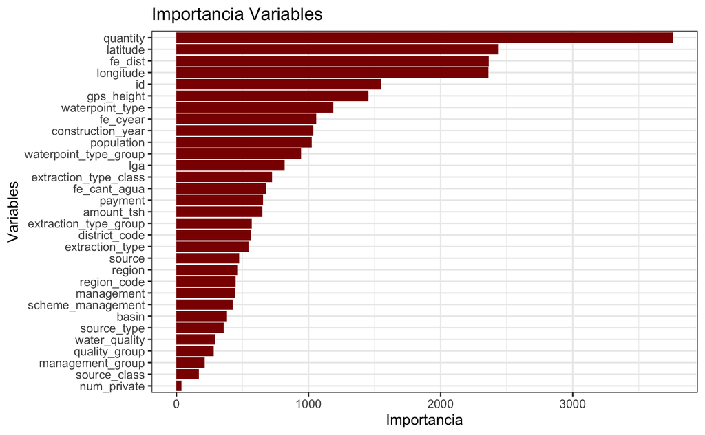

De forma general, las variables creadas se sitúan entre las variables con mayor importancia (a excepción de *fe_cant_agua*). A continuación, si analizamos las predicciones obtenidas en el conjunto test:

```r
my_sub_2 <- make_predictions(my_model_2, dattestOr)
# guardo submission
fwrite(my_sub_2, file = "../submissions/02_num_cat_menos1000_fe_cyear_dist_cant_agua.csv")
```

|  | Train.accuracy | Data.Submission |
| --- | --- | --- |
| Num + Cat (> 1 & < 1000) sin duplicados | 0.8168687 | 0.8128 |
| Num + Cat (> 1 & < 1000) sin duplicados imp | 0.8101178 | 0.8096 |
| Num + Cat (> 1 & < 1000) sin duplicados imp sin cols na | 0.8105724 | 0.8081 |
| Num + Cat (> 1 & < 1000) fe cyear + dist + cant_agua | 0.8122391 | 0.8174 |

## 2.3 Inclusión de *date_recorded*

Con la inclusión de las nuevas variables, el resultado mejoró con respecto a los dos *submission* anteriores, por lo que se decidió mantener cada una ellas. En relación con la siguiente prueba, se tomó la decisión de incluir una variable adicional que hasta el momento no se había tenido en cuenta: *date_recorded*. Dado que la variable se encuentra en formato fecha, en lugar de incluir directamente el campo se dividió en un total de tres nuevas variables:

1. **Año**
2. **Mes**
3. **Diferencia entre la fecha de observación y la fecha de construcción de la bomba**, de forma que se pueda tener una columna que indique su antigüedad en el momento en el que se insertó la fila:

```r
#-- date_recorded --> año
#   Train
dattrainOrlab$fe_dr_year <- year(dattrainOr$date_recorded)

#   Test
dattestOr$fe_dr_year     <- year(dattestOr$date_recorded)
```

```r
#-- date_recorded --> mes
#   Train
dattrainOrlab$fe_dr_month <- month(dattrainOr$date_recorded)

#   Test
dattestOr$fe_dr_month     <- month(dattestOr$date_recorded)
```

```r
#-- date_recorded --> año date_recorded - año construction_date
#   Train
dattrainOrlab$fe_dr_year_cyear_diff <- dattrainOrlab$fe_dr_year - dattrainOrlab$construction_year

#   Test
dattestOr$fe_dr_year_cyear_diff     <- dattestOr$fe_dr_year - dattestOr$construction_year
```

```r
sum(dattrainOrlab$fe_dr_year_cyear_diff < 0) # Train
```

```
## [1] 9
```

```r
sum(dattestOr$fe_dr_year_cyear_diff < 0)     # Test
```

```
## [1] 3
```

Nuevamente, tras crear las variables entrenamos el modelo *random forest*:

```r
#-- Modelo 3
my_model_3 <- fit_random_forest(formula, dattrainOrlab)
```

```
[1] 0.8115152
40.562 sec elapsed
```

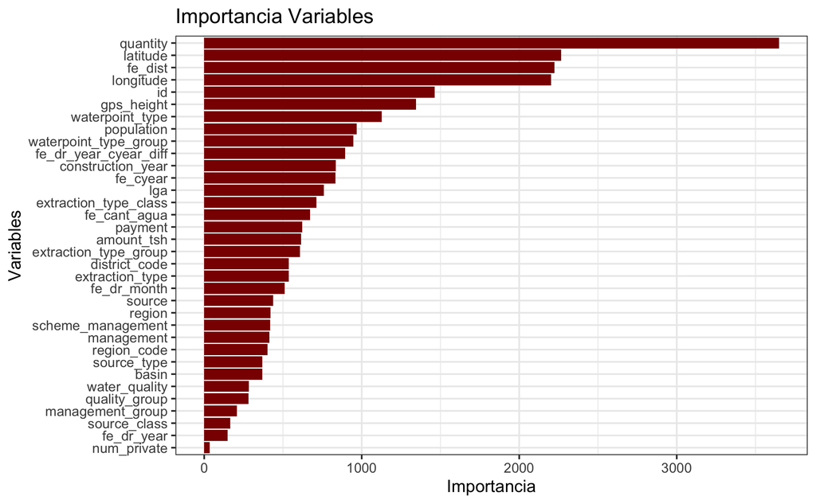

Salvo la variable *fe_dr_year* (año de *date_recorded*), por lo general son variables relevantes. Además, si analizamos el conjunto *test*:

```r
my_sub_3 <- make_predictions(my_model_3, dattestOr)
# guardo submission
fwrite(my_sub_3,
    file = "../submissions/03_num_cat_menos1000_fe_cyear_dist_cant_agua_dr_year_month_old.csv")
```

|  | Train.accuracy | Data.Submission |
| --- | --- | --- |
| Num + Cat (> 1 & < 1000) sin duplicados | 0.8168687 | 0.8128 |
| Num + Cat (> 1 & < 1000) sin duplicados imp | 0.8101178 | 0.8096 |
| Num + Cat (> 1 & < 1000) sin duplicados imp sin cols na | 0.8105724 | 0.8081 |
| Num + Cat (> 1 & < 1000) fe cyear + dist + cant_agua | 0.8122391 | 0.8174 |
| Num + Cat (> 1 & < 1000) fe cyear + dist + cant_agua + dr_year + dr_month + abs(dr_year -cyear) | 0.8115152 | 0.8176 |

Por lo general, **el modelo ha mejorado de 0.8174 a 0.8176**. Sin embargo, no todas las variables son de especial importancia, como es el caso de *fe_dr_year* ¿Y si eliminamos dicha variable?

```r
dattrainOrlab$fe_dr_year <- NULL
dattestOr$fe_dr_year     <- NULL
```

```r
# Calculamos el nuevo modelo
my_model_3_sin_dr_year <- fit_random_forest(formula, dattrainOrlab)
```

```
[1] 0.812138
39.71 sec elapsed
```

```r
my_sub_3_sin_dr_year <- make_predictions(my_model_3_sin_dr_year, dattestOr)
# guardo submission
fwrite(my_sub_3_sin_dr_year,
    file = "../submissions/03_num_cat_menos1000_fe_cyear_dist_cant_agua_month_old.csv")
```

[output not shown]

Prácticamente, obtuvimos el mismo resultado eliminando el año de *date_recorded*, por lo que se decidió no tener en cuenta dicha variable.

## 2.4 Tuneo modelo final

Como se ha podido comprobar en la tabla anterior, aumenta ligeramente el valor de **accuracy** al añadir las dos nuevas variables. Por tanto, como última *submission realizada en clase* se realizó un tuneo de hiperparámetros del modelo *random forest*, empleando todos los parámetros utilizados hasta el momento.

```r
my_ntree <- c(500, 600, 700, 800)
my_mtry  <- c(5, 6, 7, 10)
my_pars  <- expand.grid(my_ntree, my_mtry)
names(my_pars) <- c('myntree', 'mymtry')
my_pars$accuracy <- 0

for (i in 1:nrow(my_pars)) {
   my_model_tuning <- fit_random_forest(formula, dattrainOrlab,
                                        num_trees = my_pars$myntree[[i]],
                                        mtry = my_pars$mymtry[i])
   my_pars$accuracy[i] <- (1 - my_model_tuning$prediction.error)
}
rm(my_model_tuning)
```

Tras realizar el tuneo de hiperparámetros, comprobamos qué modelo obtiene un mayor *accuracy*:

```r
load("../rdata/00.RData")
my_pars[which(my_pars$accuracy == max(my_pars$accuracy)), ]
```

```
##   myntree mymtry  accuracy
## 7     700      6 0.8137374
```

```r
#-- Entrenamos el modelo con 700 arboles y mtry = 6
my_model_4 <- fit_random_forest(formula, dattrainOrlab, num_trees = 700, mtry = 6)
```

```
[1] 0.8137374
76.683 sec elapsed
```

Finalmente, analizamos el *score* de las predicciones obtenidas:

```r
my_sub_4 <- make_predictions(my_model_4, dattestOr)
# guardo submission
fwrite(my_sub_4,
    file = "../submissions/04_num_cat_menos1000_fe_tunned.csv")
```

[output not shown]

# 3. Mejora del modelo tras el concurso

## 3.1 Feature Engineering

Tras el concurso, por cuenta propia se ha decidido partir del mejor modelo obtenido hasta el momento, correspondiente con:

1. Variables numéricas
2. Variables categóricas
3. *Feature Engineering*: *cyear*, *dist*, *cant_agua*, *dr_month* y *dr_year* - *cyear*

Sobre dicho modelo, se ha obtenido una mejor puntuación de 0.812138 en el conjunto *train* y 0.8176 en el conjunto de prueba, por lo que el objetivo consistirá en superar dicho *accuracy*, junto el mejor *accuracy* alcanzado en el grupo en conjunto (0.8180), así como la mejor puntuación obtenida por el grupo ganador (0.8248).

**Importante**: con el objetivo de evitar redundancia de código, el conjunto de datos obtenidos en la fase anterior se han almacenado en ficheros csv denominados *train_values_concurso.csv* y *test_values_concurso.csv*. Además, de ahora en adelante se trabajará con *data.table* en lugar de *data.frames*, con fines únicamente didácticos (aprender una nueva estructura de datos):

```r
# Volvemos a cargar dattrainOr, ya que contiene la columna status_group
dattrainOr       <- fread(file = "../data/train_values.csv", data.table = FALSE)

dattrainOrlab    <- fread(file = "../data/train_values_concurso.csv", data.table = FALSE )
dattestOr        <- fread(file = "../data/test_values_concurso.csv", data.table = FALSE  )
```

Una vez cargados ambos datos (entrenamiento y prueba), se tomó la decisión de juntar ambos ficheros en una única variable (dat_completo), evitando de este modo la duplicidad en el código. Por tanto, y dado que el conjunto *test* no dispone de la columna *status_group*, almacenamos la variable objetivo del conjunto *train* en un vector:

```r
vector_status_group        <- dattrainOrlab$status_group
dattrainOrlab$status_group <- NULL

#-- Nos traemos funder, ward (menos de 2100 categorias)
#   Para el siguiente apartado
dattrainOrlab$funder <- dattrainOr$funder
dattrainOrlab$ward <- dattrainOr$ward

# Creamos el dataset completo (train y test unidos)
columnas_test  <- names(dattestOr)[names(dattestOr) %in% names(dattrainOrlab)]
datcompleto <- rbind(dattrainOrlab, dattestOr[, columnas_test])
datcompleto <- as.data.table(datcompleto)
```

Además, de cara a la posterior separación del conjunto *train* y *test* para el entrenamiento, almacenamos en una variable el número de fila __a partir del cual comienza el conjunto _test__:

```r
# El conjunto test empieza a partir de la 59401
# 50785: primer id del conjunto test
fila_test <- which(datcompleto$id == 50785)
```

### 3.1.1 Incluyendo variables < 2100 valores únicos

Hasta ahora, hemos incluido variables con menos de 1000 categorias únicas, esto es, hasta la variable *lga*. Durante el concurso, no se tuvieron en cuenta, dado que sel objetivo fue maximizar el *score* del modelo sin necesidad de recurrir a variables con un alto número de categorías. Por ello, de cara a la parte individual se tomó la decisión de trabajar sobre dichos campos.

Con el objetivo de seguir un orden y **no incluir todas las variables “de forma abrupta”**, comenzamos con aquellas con menos de 2100 categorías, esto es, *funder* y *ward*:

```r
#--- Niveles de las categoricas.
datcat_df <- as.data.frame(datcompleto %>% select(where(is.character)))

numlev_df <- data.frame()
for (i in 1:ncol(datcat_df)) {
  col_tmp <- datcat_df[, i]
  num_lev <- length(unique(col_tmp))
  numlev_df[i, 1] <- names(datcat_df)[i]
  numlev_df[i, 2] <- num_lev
}
names(numlev_df) <- c('vars', 'levels')
numlev_df %>% arrange(levels)
```

```
##                     vars levels
## 1           source_class      3
## 2       management_group      5
## 3               quantity      5
## 4          quality_group      6
## 5  waterpoint_type_group      6
## 6  extraction_type_class      7
## 7                payment      7
## 8            source_type      7
## 9        waterpoint_type      7
## 10         water_quality      8
## 11                 basin      9
## 12                source     10
## 13            management     12
## 14     scheme_management     13
## 15 extraction_type_group     13
## 16       extraction_type     18
## 17                region     21
## 18                   lga    125
## 19                  ward   2098
## 20                funder   2141
```

Dado que existen demasiadas categorías, podemos preguntarnos si realmente existen 2098 y 2141 valores unicos en *ward* y *funder*, respectivamente. De hecho, podemos comprobar como algunas de las categorías se diferencian por tan solo una o dos palabras:

```
Lgcdg   - Lgcbg  # En el caso de funder
Magole  - Magoma # En el caso de ward
```

Es decir, se tratan de regiones “alfabeticamente” muy similares. Por tanto, ¿quién nos asegura que dos o más categorías se diferencien por tan solo un espacio en blanco, una palabra en mayúscula o por signos de puntuación? Como consecuencia, antes de procesar un modelo se tomó la decisión de **realizar una limpieza sobre ambas columnas, con el propósito de comprobar si se reduce el número de valores únicos**. Para ello, empleamos la librería **stringi**, creando una función que permita filtrar:

1. Mayúsculas
2. Espacios en blanco
3. Signos de puntuación

```r
# Funcion para limpieza de strings (vectorizado)
clean_text <- function(text) {
  stri_trans_tolower(
    stri_replace_all_regex(
      text,
      pattern = "[ +\\p{Punct}]",
      replacement = ""
      )
    )
}
```

Una vez creada la función,la aplicamos sobre el *data.table*:

```r
datcompleto[, fe_funder := clean_text(funder)][, fe_ward := clean_text(ward)]
```

Tras aplicar dicha función, comprobamos si el número de categorías se ha visto reducido:

```r
datcat_df <- as.data.frame(datcompleto %>% select(where(is.character)))

numlev_df <- data.frame()
for (i in 1:ncol(datcat_df)) {
  col_tmp <- datcat_df[, i]
  num_lev <- length(unique(col_tmp))
  numlev_df[i, 1] <- names(datcat_df)[i]
  numlev_df[i, 2] <- num_lev
}
names(numlev_df) <- c('vars', 'levels')
numlev_df %>% arrange(levels)
```

```
##                     vars levels
## 1           source_class      3
## 2       management_group      5
## 3               quantity      5
## 4          quality_group      6
## 5  waterpoint_type_group      6
## 6  extraction_type_class      7
## 7                payment      7
## 8            source_type      7
## 9        waterpoint_type      7
## 10         water_quality      8
## 11                 basin      9
## 12                source     10
## 13            management     12
## 14     scheme_management     13
## 15 extraction_type_group     13
## 16       extraction_type     18
## 17                region     21
## 18                   lga    125
## 19               fe_ward   2096
## 20                  ward   2098
## 21             fe_funder   2110
## 22                funder   2141
```

Analizando la salida anterior, podemos comprobar como el número de categorías se ha visto reducido ligeramente en ambas columnas:

Una vez creadas las nuevas columnas, eliminamos las originales y lanzamos el modelo:

```r
datcompleto[, c("ward", "funder") := NULL]
```

```r
#-- Modelo
# Dividimos entre conjunto de entrenamiento y prueba
train <- datcompleto[c(1:fila_test-1),]
train$status_group <- vector_status_group
train$status_group <- as.factor(train$status_group)

test <- datcompleto[c(fila_test:nrow(datcompleto)),]

formula   <- as.formula("status_group~.")

# Empleamos la funcion fit_random_forest definida anteriormente
my_model_5 <- fit_random_forest(formula, train)
```

```
[1] 0.8149832
39.414 sec elapsed
```

Tras crear el modelo, echemos un vistazo a la importancia de las variables:

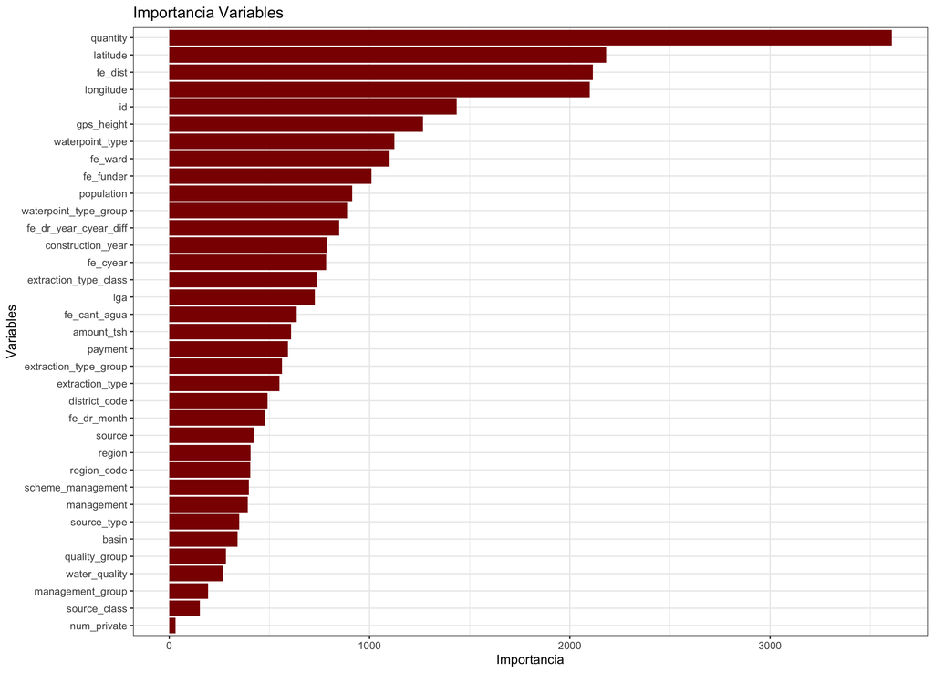

Observamos que ambas variables se sitúan entre las variables con mayor relevancia (importancia en torno a 1000). Veamos si con el conjunto *test* obtenemos un mejor *score*:

```r
my_sub_5 <- make_predictions(my_model_5, dattestOr)
# guardo submission
fwrite(my_sub_5,
    file = "../submissions/05_04_mas_fe_inst_funder_scheme_ward.csv")
```

|  | Train.accuracy | Data.Submission |
| --- | --- | --- |
| Mejor accuracy en el concurso | - | 0.8180 |
| Num + Cat (> 1 & < 2100) fe anteriores + fe_funder + fe_ward | 0.8149832 | 0.8197 |

Aparentemente, hemos conseguido un mejor *score* que el obtenido en clase.

### 3.1.2 Aplicando lumping sobre ward y funder (mediana)

```r
prop_categorias_ward   <- summary(c(prop.table(table(datcompleto[, fe_ward])))) # fe_ward
prop_categorias_ward
```

```
##      Min.   1st Qu.    Median      Mean   3rd Qu.      Max.
## 1.347e-05 1.751e-04 3.367e-04 4.771e-04 6.330e-04 5.199e-03
```

```r
prop_categorias_funder <- summary(c(prop.table(table(datcompleto[, fe_funder])))) # fe_funder
prop_categorias_funder
```

```
##      Min.   1st Qu.    Median      Mean   3rd Qu.      Max.
## 1.347e-05 1.347e-05 1.347e-05 4.739e-04 9.428e-05 1.522e-01
```

Observamos que **muchas de las categorías aperecen con muy poca frecuencia**. Por ejemplo, si nos fijamos en la mediana vemos que la mitad de las categorías de *fe_ward* aparecen con una proporción igual o inferior a 3.37e-04, así como en *fe_funder*, con una proporción aún más pequeña (del orden de 1e-5).

Por tanto, una posibilidad sería **aplicar lumping sobre aquellas categorías con una proporción de aparición muy pequeña**, agrupándose en torno a una única categoría ( *other* ). En un primer comienzo, podemos aplicarlo sobre la mediana. Por ejemplo, en el caso de la variable *ward*, dado que la mediana se sitúa en torno a 3.367e-04, aplicamos *lumping* **a partir de aquellas categorías con una proporción inferior a 4e-04, de forma aproximada**, haciendo uso de la función *fct_lump_prop* del paquete *forcats*:

```r
#-- fe_ward
datcompleto[, fe_ward := fct_lump_prop(datcompleto[,fe_ward], 4e-04, other_level = "other")]
datcompleto$fe_ward <- as.character(datcompleto$fe_ward)

# Pasamos de 2096 a 904 categorias (menos de la mitad de categorias)
sum(length(unique(datcompleto[, fe_ward])))
```

```
## [1] 904
```

En el caso de *funder*, aproximamos a 2e-05:

```r
#-- fe_funder
datcompleto[, fe_funder := fct_lump_prop(datcompleto[,fe_funder], 2e-05, other_level = "other")]
datcompleto$fe_funder <- as.character(datcompleto$fe_funder)

# Pasamos de 2110 a 999 categorias (menos de la mitad de categorias)
sum(length(unique(datcompleto[, fe_funder])))
```

```
## [1] 999
```

Como podemos comprobar, **conseguimos reducir significativamente el número de categorías en ambas variables**. Una vez aplicado *lumping* sobre dichas columnas, lanzamos nuevamente un modelo *Random Forest*:

```r
#-- Modelo
# Dividimos entre conjunto de entrenamiento y prueba
train <- datcompleto[c(1:fila_test-1),]
train$status_group <- vector_status_group
train$status_group <- as.factor(train$status_group)

test <- datcompleto[c(fila_test:nrow(datcompleto)),]

formula   <- as.formula("status_group~.")

# Empleamos la funcion fit_random_forest definida anteriormente
my_model_6 <- fit_random_forest(formula, train)
```

```
[1] 0.8159764
39.081 sec elapsed
```

En relación con el modelo anterior, el hecho de disminuir el número de categorías ha mejorado el resultado en el conjunto *train* (pasando de 0.8149832 a 0.8159764). A continuación, analicemos el conjunto *test*:

```r
my_sub_6 <- make_predictions(my_model_5, dattestOr)
# guardo submission
fwrite(my_sub_6,
    file = "../submissions/06_lumping_y_fe_sobre_funder_ward_mediana.csv")
```

|  | Train.accuracy | Data.Submission |
| --- | --- | --- |
| Mejor accuracy en el concurso | - | 0.8180 |
| Num + Cat (> 1 & < 2100) fe anteriores + fe_funder + fe_ward | 0.8149832 | 0.8197 |
| Num + Cat (> 1 & < 2100) fe anteriores + lumping sobre funder + ward (mediana) | 0.8159764 | 0.8212 |

**Observamos que incluso en el conjunto *test* el *score* ha aumentado a 0.8212**.

### 3.1.3 Aplicando lumping sobre ward y funder (primer y tercer cuartil)

En el apartado anterior, aplicamos *lumping* sobre aquellas categorías cuya proporción de aparición se situase por debajo de la mediana, aproximadamente. No obstante, ¿Y si aplicamos el punto de corte sobre el primer o tercer cuartil? Es decir, si recordamos la salida del *summary* anterior:

```r
prop_categorias_ward   # fe_ward
```

```
##      Min.   1st Qu.    Median      Mean   3rd Qu.      Max.
## 1.347e-05 1.751e-04 3.367e-04 4.771e-04 6.330e-04 5.199e-03
```

```r
prop_categorias_funder # fe_funder
```

```
##      Min.   1st Qu.    Median      Mean   3rd Qu.      Max.
## 1.347e-05 1.347e-05 1.347e-05 4.739e-04 9.428e-05 1.522e-01
```

Podríamos aplicar *lumping* sobre el primer cuartil, de forma aproximada, o bien sobre el tercer cuartil. De este modo, **podemos comprobar si agrupando un mayor o menor número de categorías conseguimos mejorar la puntuación** (“jugar con el punto de corte”).

#### 3.1.3.1 Sobre el primer cuartil

```r
#-- fe_ward (primer cuartil: 1.751e-04, aplicamos el punto de corte sobre 2e-04 aprox.)
datcompleto[, fe_ward := fct_lump_prop(datcompleto[,fe_ward], 2e-04, other_level = "other")]
datcompleto$fe_ward <- as.character(datcompleto$fe_ward)

# Pasamos de 2096 a 1483 categorias
sum(length(unique(datcompleto[, fe_ward])))
```

```
## [1] 1483
```

```r
#-- fe_funder (primer cuartil: 1.347e-05, aplicamos el punto de corte sobre 2e-05 aprox.)
datcompleto[, fe_funder := fct_lump_prop(datcompleto[,fe_funder], 2e-05, other_level = "other")]
datcompleto$fe_funder <- as.character(datcompleto$fe_funder)

# Pasamos de 2110 a 999 categorias (primer cuartil = mediana)
sum(length(unique(datcompleto[, fe_funder])))
```

```
## [1] 999
```

Una vez aplicado *lumping*, recalculamos el modelo:

```r
#-- Modelo
# Dividimos entre conjunto de entrenamiento y prueba
train <- datcompleto[c(1:fila_test-1),]
train$status_group <- vector_status_group
train$status_group <- as.factor(train$status_group)

test <- datcompleto[c(fila_test:nrow(datcompleto)),]

formula   <- as.formula("status_group~.")
# Resultado train: 0.8159259
my_model_7 <- fit_random_forest(formula,
                                train)

my_sub_7 <- make_predictions(my_model_7, test)

fwrite(my_sub_7, file = "./submissions/07_lumping_y_fe_sobre_funder_ward_primer_cuartil.csv")
# Score: 0.8196
```

```r
knitr::kable(data.frame("Train accuracy" = c(0.8159764, 0.8159259),
                        "Data Submission" = c(0.8212, 0.8196),
                        row.names = c("lumping sobre mediana",
                                      "lumping sobre primer cuartil")),
             align = 'c')
```

|  | Train.accuracy | Data.Submission |
| --- | --- | --- |
| lumping sobre mediana | 0.8159764 | 0.8212 |
| lumping sobre primer cuartil | 0.8159259 | 0.8196 |

Observamos que manteniendo un mayor número de categorías, el *score* obtenido tanto en *train* como en *test* empeora.

#### 3.1.3.2 Sobre el tercer cuartil

```r
#-- fe_ward (primer cuartil: 6.330e-04, aplicamos el punto de corte sobre 7e-04 aprox.)
datcompleto[, fe_ward := fct_lump_prop(datcompleto[,fe_ward], 7e-04, other_level = "other")]
datcompleto$fe_ward <- as.character(datcompleto$fe_ward)

# Pasamos de 2096 a 452 categorias
sum(length(unique(datcompleto[, fe_ward])))
```

```
## [1] 452
```

```r
#-- fe_funder (primer cuartil: 9.428-05, aplicamos el punto de corte sobre 1e-04 aprox.)
datcompleto[, fe_funder := fct_lump_prop(datcompleto[,fe_funder], 1e-04, other_level = "other")]
datcompleto$fe_funder <- as.character(datcompleto$fe_funder)

# Pasamos de 2110 a 502 categorias
sum(length(unique(datcompleto[, fe_funder])))
```

```
## [1] 502
```

```r
#-- Modelo
# Dividimos entre conjunto de entrenamiento y prueba
train <- datcompleto[c(1:fila_test-1),]
train$status_group <- vector_status_group
train$status_group <- as.factor(train$status_group)

test <- datcompleto[c(fila_test:nrow(datcompleto)),]

formula   <- as.formula("status_group~.")
# Resultado train: 0.8146633
my_model_8 <- fit_random_forest(formula,
                                train)

my_sub_8 <- make_predictions(my_model_8, test)

fwrite(my_sub_8, file = "./submissions/08_lumping_y_fe_sobre_funder_ward_tercer_cuartil.csv")
# Score: 0.8203
```

```r
knitr::kable(data.frame("Train accuracy" = c(0.8159764, 0.8159259, 0.8146633),
                        "Data Submission" = c(0.8212, 0.8196, 0.8203),
                        row.names = c("lumping sobre mediana",
                                      "lumping sobre primer cuartil",
                                      "lumping sobre tercer cuartil")),
             align = 'c')
```

|  | Train.accuracy | Data.Submission |
| --- | --- | --- |
| lumping sobre mediana | 0.8159764 | 0.8212 |
| lumping sobre primer cuartil | 0.8159259 | 0.8196 |
| lumping sobre tercer cuartil | 0.8146633 | 0.8203 |

Comprobamos que, pese a mejorar el *score* del modelo al aplicar el punto de corte sobre el tercer cuartil, el resultado obtenido sobre la mediana continua siendo mejor.

Por tanto, **sobre las variables *fe_ward* y *fe_funder* aplicamos *lumping* sobre la mediana de proporción de aparición de cada una de sus categorías**, reduciendo el número a 904 y 999, respectivamente.

|  | Train.accuracy | Data.Submission |
| --- | --- | --- |
| Mejor accuracy en el concurso | - | 0.8180 |
| Num + Cat (> 1 & < 2100) fe anteriores + fe_funder + fe_ward | 0.8149832 | 0.8197 |
| Num + Cat (> 1 & < 2100) fe anteriores + lumping sobre funder + ward (mediana) | 0.8159764 | 0.8212 |
| Num + Cat (> 1 & < 2100) fe anteriores + lumping sobre funder + ward (primer cuartil) | 0.8159259 | 0.8196 |
| Num + Cat (> 1 & < 2100) fe anteriores + lumping sobre funder + ward (tercer cuartil) | 0.8146633 | 0.8203 |

Pese a aplicar *lumping* sobre ambas variables, continuamos teniendo demasiadas categorías: 904 en el caso de *fe_ward* y 999 en el caso de *fe_funder*. Como consecuencia, se plantearon diversas alternativas con el fin de reducir nuevamente el número de valores únicos sobre dichas columnas, observando con ello si el *score* obtenido mejora:

1. *Hashing encoding*
2. *Frecuencias absolutas*
3. *Target encoding*
4. *Word Embedding*